# INTRODUCTION

[Bellabeat](https://bellabeat.com/) is a high-tech manufacturer of health-focused products for women. The CCO and cofounder of Bellabeat, Urska Srsen, believes the company is well positioned to gain additional market share through thoughtful analysis of wearable smart device data. The marketing strategy will use this analysis as guidance.

As a junior data analyst with just 6 months with the company, I have been tasked with analyzing smart device data and developing high-level recommendations to inform marketing strategies. The scope has been limited to a single product line.

I have found a dataset from [Fitbit](https://store.google.com/category/watches_trackers?hl=en-US&utm_source=fitbit_redirect&utm_medium=google_ooo&utm_campaign=category) (a wearable watch) that has similar features to Bellabeat’s *Time*. The dataset contains no demographic information and has a very limited number of unique participants. We *assume* the sample population is representative though additional data might prove this assumption inaccurate. The fitbit dataset is publicly available as Fitbit Fitness Tracker Data.

What follows is a reproducible examination of the data contained within the fitbit dataset, how we went about fixing oversights with cleaning and processing the data when they arose. We hope to highlight identified limitations in the analyzed data, and any problems which should be considered before a go-forward marketing strategy is deployed.

# ASK

**Business Task or Problem**

Analyze competitor data to identify and evaluate user trends, opportunity areas, and glean insights to inform Bellabeat’s grow-forward marketing strategies as relates to our wearable watch, *Time*. Because *Time* connects directly to the Bellabeat app, the data analysis performed can also inform system changes.

The stakeholders have been identified as the ownership team and the marketing analytics team. The dataset being evaluated is public so there are no security concerns. If there was an actual gap-to-target, formalized problem-solving would have to occur.

**Key Questions:** - What are the features being utilized and at what rates? - Is there statistically significant variance which requires additional data to resolve? - What impacts are expected with no demographic information available to analyze?

# PREPARE

Evaluating the data by day of the week and, where available and relevant, hour by hour allowed the most granular assessment – with our notably limited skillset – possible.

**Let’s get started!**

```r
# One bit of housekeeping: we will run an options code to size our data viz plots.
options(repr.plot.width = 12, repr.plot.height = 8)
```

```r
# Load libraries (the tidyverse has readr, janitor,ggplot,dplyr,lubridate etc built-in) so most of this list is redundant.
library(tidyverse)
library(lubridate)
library(dplyr)
library(magrittr)
library(hms)
library(rmarkdown)
library(reticulate)
```

```r
activity <- read_csv("/kaggle/input/fitbit/mturkfitbit_export_4.12.16-5.12.16/Fitabase Data 4.12.16-5.12.16/dailyActivity_merged.csv")
 head(activity)
```

```
## # A tibble: 6 × 15
##           Id ActivityDate TotalSteps TotalDistance TrackerDistance
##        <dbl> <chr>             <dbl>         <dbl>           <dbl>
## 1 1503960366 4/12/2016         13162          8.5             8.5
## 2 1503960366 4/13/2016         10735          6.97            6.97
## 3 1503960366 4/14/2016         10460          6.74            6.74
## 4 1503960366 4/15/2016          9762          6.28            6.28
## 5 1503960366 4/16/2016         12669          8.16            8.16
## 6 1503960366 4/17/2016          9705          6.48            6.48
## # ℹ 10 more variables: LoggedActivitiesDistance <dbl>,
## #   VeryActiveDistance <dbl>, ModeratelyActiveDistance <dbl>,
## #   LightActiveDistance <dbl>, SedentaryActiveDistance <dbl>,
## #   VeryActiveMinutes <dbl>, FairlyActiveMinutes <dbl>,
## #   LightlyActiveMinutes <dbl>, SedentaryMinutes <dbl>, Calories <dbl>
```

```r
sleep <- read_csv("/kaggle/input/fitbit/mturkfitbit_export_4.12.16-5.12.16/Fitabase Data 4.12.16-5.12.16/sleepDay_merged.csv")
 head(sleep)
```

```
## # A tibble: 6 × 5
##           Id SleepDay        TotalSleepRecords TotalMinutesAsleep TotalTimeInBed
##        <dbl> <chr>                       <dbl>              <dbl>          <dbl>
## 1 1503960366 4/12/2016 12:0…                 1                327            346
## 2 1503960366 4/13/2016 12:0…                 2                384            407
## 3 1503960366 4/15/2016 12:0…                 1                412            442
## 4 1503960366 4/16/2016 12:0…                 2                340            367
## 5 1503960366 4/17/2016 12:0…                 1                700            712
## 6 1503960366 4/19/2016 12:0…                 1                304            320
```

```r
hourly_intensities <- read_csv("/kaggle/input/fitbit/mturkfitbit_export_4.12.16-5.12.16/Fitabase Data 4.12.16-5.12.16/hourlyIntensities_merged.csv")
 head(hourly_intensities)
```

```
## # A tibble: 6 × 4
##           Id ActivityHour          TotalIntensity AverageIntensity
##        <dbl> <chr>                          <dbl>            <dbl>
## 1 1503960366 4/12/2016 12:00:00 AM             20            0.333
## 2 1503960366 4/12/2016 1:00:00 AM               8            0.133
## 3 1503960366 4/12/2016 2:00:00 AM               7            0.117
## 4 1503960366 4/12/2016 3:00:00 AM               0            0
## 5 1503960366 4/12/2016 4:00:00 AM               0            0
## 6 1503960366 4/12/2016 5:00:00 AM               0            0
```

```r
steps <- read_csv("/kaggle/input/fitbit/mturkfitbit_export_4.12.16-5.12.16/Fitabase Data 4.12.16-5.12.16/hourlySteps_merged.csv")
 head(steps)
```

```
## # A tibble: 6 × 3
##           Id ActivityHour          StepTotal
##        <dbl> <chr>                     <dbl>
## 1 1503960366 4/12/2016 12:00:00 AM       373
## 2 1503960366 4/12/2016 1:00:00 AM        160
## 3 1503960366 4/12/2016 2:00:00 AM        151
## 4 1503960366 4/12/2016 3:00:00 AM          0
## 5 1503960366 4/12/2016 4:00:00 AM          0
## 6 1503960366 4/12/2016 5:00:00 AM          0
```

```r
weight <- read_csv("/kaggle/input/fitbit/mturkfitbit_export_4.12.16-5.12.16/Fitabase Data 4.12.16-5.12.16/weightLogInfo_merged.csv")
 head(weight)
```

```
## # A tibble: 6 × 8
##           Id Date       WeightKg WeightPounds   Fat   BMI IsManualReport   LogId
##        <dbl> <chr>         <dbl>        <dbl> <dbl> <dbl> <lgl>            <dbl>
## 1 1503960366 5/2/2016 …     52.6         116.    22  22.6 TRUE           1.46e12
## 2 1503960366 5/3/2016 …     52.6         116.    NA  22.6 TRUE           1.46e12
## 3 1927972279 4/13/2016…    134.          294.    NA  47.5 FALSE          1.46e12
## 4 2873212765 4/21/2016…     56.7         125.    NA  21.5 TRUE           1.46e12
## 5 2873212765 5/12/2016…     57.3         126.    NA  21.7 TRUE           1.46e12
## 6 4319703577 4/17/2016…     72.4         160.    25  27.5 TRUE           1.46e12
```

**The datasets have a few easily discernible issues: The date and datetime fields are not in a useful data type for further analysis (the dates/times are in character strings). Additionally, column names vary from dataframe to dataframe. The last key point to be made at this point is that weekday information about the specified dates cannot be culled without further manipulation of the data.**

For ‘activity’ we will need to change activity date from character to date, then add a column identifying the weekday the date is associated with.

# PROCESS

## Daily Activity

**As we identified in our preliminary look (head) the column titled ActivityDate is a character string. There are surely better ways to clean data than my iterative approach but I am new to the R programming language so my coding is quite clunky and inefficient.**

```r
activity <- activity %>% mutate(ActivityDate = mdy(ActivityDate))
```

```r
# Add labels to ensure each day of the week is written as a day "TRUE" and no abbreviations are used "FALSE"
activity <- activity %>%
  mutate(day_of_week = wday(ActivityDate, label = TRUE, abbr = FALSE))
```

```r
# Add a column called 'Active Hours' to the activity dataframe. This column is a sum of all the active minutes/60.
activity <- activity %>% mutate(ActiveHours = (VeryActiveMinutes + FairlyActiveMinutes + LightlyActiveMinutes) / 60)
# Add a column called "SedentaryHours"
activity <- activity %>% mutate(SedentaryHours = SedentaryMinutes / 60)
```

```r
activity <- activity %>%
  mutate(day_of_week = wday(ActivityDate, label = TRUE, abbr = FALSE))
```

**Lastly, let’s change the name of the date column. This will assist us later on in analysis.**

```r
activity <- activity %>%
        rename(Date = ActivityDate)
```

```r
# View(activity)
```

**Now let’s turn our attention to the sleep day data. We will clean it in a similar, iterative, way.**

## 4.2 Daily Sleep

**We first want to mutate SleepDay (which has the date and time fields in a single column as a character string) into two separate columns that we can manipulate as needed.**

```r
sleep <- sleep %>% separate(SleepDay, into = c("Date", "Time"), sep = " ")
sleep <- sleep %>% mutate(Date = mdy(Date))
```

**Add a column for day of week**

```r
sleep <- sleep %>%
  mutate(day_of_week = wday(Date, label = TRUE, abbr = FALSE))
```

**For an apples to apples comparison later, let’s make sure to add a column that converts sleep minutes to sleep hours, total time in bed to hours and we will call the difference between being in bed and being asleep the winddown time.**

```r
sleep <- sleep %>% mutate(SleepHours = (TotalMinutesAsleep / 60),
                          InBedHours = (TotalTimeInBed / 60),
                          WindDown = (InBedHours - SleepHours))
```

## 4.3 Hourly Intensities

```r
# Step 1: Separate the date and time from the original column.
hourly_intensities <- hourly_intensities %>%
   separate(ActivityHour, into = c("ActivityDate", "ActivityTime"), sep = " ", extra = "merge")
```

```r
# Change the data type of ActivityDate
hourly_intensities <- hourly_intensities %>%
   mutate(ActivityDate = mdy(ActivityDate))
```

**Add a weekday column. The ‘label= true’ means your output will return the name of a day (not a numerical value) and ‘abbr=false’ means abbreviations will not be returned.**

```r
hourly_intensities <- hourly_intensities %>%
   mutate(day_of_week = wday(ActivityDate, label = TRUE, abbr = FALSE))
```

**The time needs to be split out so you can see that am and pm are somehow identifiable. In this case, I’ve use a 24 hour approach to solving the problem.**

```r
hourly_intensities <- hourly_intensities %>%
   mutate(ActivityTime = as_hms(parse_date_time(ActivityTime, "I:M:S p")))
```

```r
hourly_intensities <- hourly_intensities %>%
        rename(Date = ActivityDate)
```

```r
# If needed use this to check that the date data type has been applied:
 str(hourly_intensities$Date)
```

```
##  Date[1:22099], format: "2016-04-12" "2016-04-12" "2016-04-12" "2016-04-12" "2016-04-12" ...
```

## Hourly Steps

**Because we’ve been through my cleaning process, let’s cut to the quick with hourly steps.**

```r
steps <- steps %>%
   separate(ActivityHour, into = c("ActivityDate", "ActivityTime"), sep = " ", extra = "merge") %>%
   mutate(ActivityDate = mdy(ActivityDate)) %>%
   mutate(ActivityTime = as_hms(parse_date_time(ActivityTime, "I:M:S p"))) %>%
   mutate(day_of_week = wday(ActivityDate, label = TRUE, abbr = FALSE)) %>%
   rename(Date = ActivityDate)
```

## Weight Log

**The weight log data is limited as seen below. We will however use the unique user/day data in our data viz in the analyze section. In order to accomplish this, we need to transform the Date column from a character type string to a date. We will add the day of the week column as well.**

```r
weight <- weight %>% separate(Date, into = c("Date", "Time"), sep = " ") %>%
  mutate(Date = mdy(Date)) %>%
  mutate(day_of_week = wday(Date, label = TRUE, abbr = FALSE))
n_distinct(weight$Id)
```

```
## [1] 8
```

**Now let’s put our efforts to use in compiling summaries and looking at how the data interacts.**

# ANALYZE (Merging and Transforming Summaries)

```r
# Summarize avg_steps and avg_calories by day of week (na.rm=remove any missing or uncalculated values)
activity_weekly_averages <- activity %>%
  group_by(day_of_week) %>%
  summarise(
    avg_steps = mean(TotalSteps, na.rm = TRUE),
    avg_calories = mean(Calories, na.rm = TRUE))
```

```r
# View(activity_weekly_averages)
```

**What can we learn about the sleep habits of Fitbit users that can be applied to our strategic marketing initiatives?**

```r
# Summary of Sleep Hours/weekday
sleep_averages <- sleep %>%
  group_by(day_of_week) %>%
  summarise(avg_sleep = mean(SleepHours, na.rm = TRUE),
            avg_time_in_bed = mean(InBedHours, na.rm = TRUE),
            avg_winddown = mean(WindDown, na.rm = TRUE))
```

```r
# View(sleep_averages)
```

**Late addition, added a winddown percent to see if there is significant variance.**

```r
sleep_averages <- sleep_averages %>%
  mutate(winddown_percent = (avg_winddown / avg_time_in_bed) * 100)
```

**In order to make a stacked bar graph available, let’s transform our sleep data into long format. This will allow us to visualize the processed data better when we create our graphs for analysis.**

```r
# The long format is ideal when you want to create a single column (in this case "metric") to group by.
sleep_averages_long <- sleep_averages %>%
  pivot_longer(
    cols = c(avg_sleep, avg_winddown),
    names_to = "metric",
    values_to = "hours"
  )
```

```r
# Summarize avg_steps and avg_calories by day of week (na.rm=remove any missing or uncalculated values)
activity_weekly_averages <- activity %>%
  group_by(day_of_week) %>%
  summarise(
    avg_steps = mean(TotalSteps, na.rm = TRUE),
    avg_calories = mean(Calories, na.rm = TRUE))
```

```r
# View(activity_weekly_averages)
```

**Average the hourly intensity data so we can visualize the data.**

```r
intensities_averages <- hourly_intensities %>%
   group_by(day_of_week, ActivityTime) %>%
   summarise(avg_total_intensity = mean(TotalIntensity, na.rm = TRUE))
```

**Average daily steps**

```r
step_averages <- steps %>%
   group_by(day_of_week, ActivityTime) %>%
   summarise(avg_step_total = mean(StepTotal, na.rm = TRUE))
```

**Our next steps involve full joins of data frames to evaluate relationships between data and summary information. NOTE: It is important to pass a vector to the “by” statement – The vector is the “c”. If you don’t do this, you will have a lot of duplicate rows.**

```r
merged_activitySleep <- full_join(activity, sleep, by = c("Id", "Date"))
```

```r
merged_data_all <- activity %>%
  full_join(sleep, by = c("Id", "Date")) %>%
  full_join(steps, by = c("Id", "Date")) %>%
  full_join(hourly_intensities, by = c("Id", "Date"))
```

**We see several users log sleep at a different rate than their activity is recorded. This needs further investigating. It appears the applications requiring the user to do more than wear the watch are not utilized as much as the applications that automatically catalog data.**

**First, let’s look at distinct users per day.**

```r
activity_distinct_users_per_day <- activity %>%
  group_by(Date) %>%
  summarise(activity_distinct_users = n_distinct(Id))

sleep_distinct_users_per_day <- sleep %>%
  group_by(Date) %>%
  summarise(sleep_distinct_users_per_day = n_distinct(Id))

intensities_distinct_users_per_day <- hourly_intensities %>%
  group_by(Date) %>%
  summarise(intensities_distinct_users_per_day = n_distinct(Id))

steps_distinct_users_per_day <- steps %>%
  group_by(Date) %>%
  summarise(steps_distinct_users_per_day = n_distinct(Id))

weight_distinct_users_per_day <- weight %>%
  group_by(Date) %>%
  summarise(weight_distinct_users_per_day = n_distinct(Id))
```

```r
activity_distinct_users_per_day <- activity_distinct_users_per_day %>%
  rename(distinct_users = names(.)[2]) %>%
  mutate(source = "activity")

sleep_distinct_users_per_day <- sleep_distinct_users_per_day %>%
  rename(distinct_users = names(.)[2]) %>%
  mutate(source = "sleep")

intensities_distinct_users_per_day <- intensities_distinct_users_per_day %>%
  rename(distinct_users = names(.)[2]) %>%
  mutate(source = "hourly_intensities")

steps_distinct_users_per_day <- steps_distinct_users_per_day %>%
  rename(distinct_users = names(.)[2]) %>%
  mutate(source = "steps")

weight_distinct_users_per_day <- weight_distinct_users_per_day %>%
  rename(distinct_users = names(.)[2]) %>%
  mutate(source = "weight")
```

**Create a summary of distinct users per application per day.**

```r
combined_distinct_user_data <- bind_rows(
  activity_distinct_users_per_day,
  sleep_distinct_users_per_day,
  intensities_distinct_users_per_day,
  steps_distinct_users_per_day,
  weight_distinct_users_per_day)
```

**Create a dataframe with usage rates by application. n_distinct Id’s by application are 33 for activity, steps, and hourly intensities, 24 for sleep, and 8 for weight. The different amount of total users is built into the code.**

```r
combined_distinct_data_with_percent <- combined_distinct_user_data %>%
  mutate(
    percent_of_users = case_when(
      source %in% c("activity", "hourly_intensities", "steps") ~ (distinct_users / 33) * 100,
      source == "sleep" ~ (distinct_users / 24) * 100,
      source == "weight" ~ (distinct_users / 8) * 100
    )
  ) %>%
  mutate(
    percent_of_users = round(percent_of_users, 0)
  )
```

We need an average use rate to complete our visual.

```r
average_use_rate <- combined_distinct_data_with_percent %>%
  group_by(source) %>%
  summarise(
    average_percent = mean(percent_of_users, na.rm = TRUE)
  )
```

```r
# View(average_use_rate) # Manual inputs are required for sleep and weight.
```

# SHARE

**Data Viz**

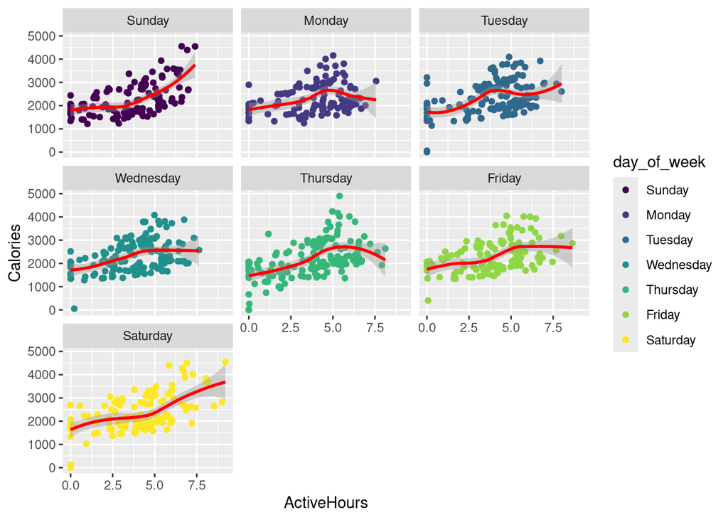

```r
# Let's look at calories and active hours by day of the week to ensure each of the days shows a positive correlation. They do.
print(ggplot(data = activity, mapping = aes(x = ActiveHours, y = Calories, color = day_of_week)) +
  geom_point() +
  facet_wrap(~ day_of_week) +
  geom_smooth(color = "red")
      )
```

**Active hours and calories burned shows a positive correlation as expected. No new insights gained.**

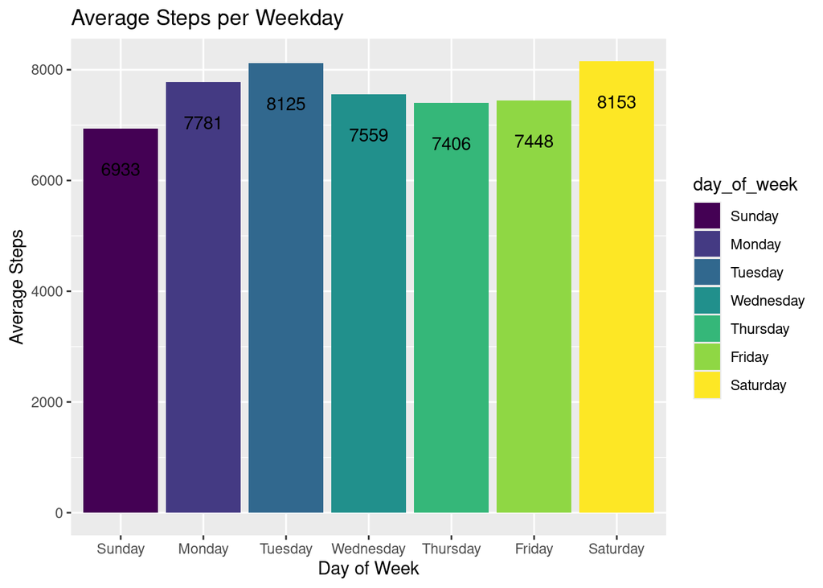

```r
# Average Steps per Weekday
print(ggplot(data = activity_weekly_averages, mapping = aes(x = day_of_week, y = avg_steps, fill = day_of_week)) +
  geom_col() +
  labs(title = "Average Steps per Weekday", x = "Day of Week", y = "Average Steps") +
  geom_text(aes(label = round(avg_steps, 0)), vjust = 3.5)
      )
```

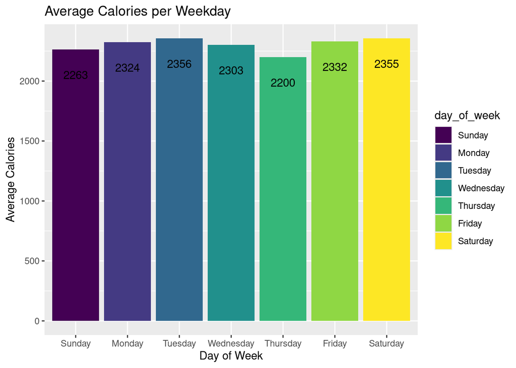

```r
# Average Calories per Weekday
print(ggplot(data = activity_weekly_averages, mapping = aes(x = day_of_week, y = avg_calories, fill = day_of_week)) +
  geom_col() +
  labs(title = "Average Calories per Weekday", x = "Day of Week", y = "Average Calories") +
  geom_text(aes(label = round(avg_calories, 0)), vjust = 3.5)
      )
```

**While it doesn’t appear there is a statistical difference between day of the week and average steps and calories, let’s run a test to ensure there is nothing of note between the variance.**

```r
# We will perform an ANOVA test on total steps relative to day of the week and ditto for calories and day of the week.
anova_steps <- aov(TotalSteps ~ day_of_week, data = activity)
summary(anova_steps)
```

```
##              Df    Sum Sq  Mean Sq F value Pr(>F)
## day_of_week   6 1.449e+08 24145583   0.933  0.471
## Residuals   933 2.416e+10 25890251
```

```r
anova_calories <- aov(Calories ~ day_of_week, data = activity)
summary(anova_calories)
```

```
##              Df    Sum Sq Mean Sq F value Pr(>F)
## day_of_week   6   2686242  447707   0.867  0.518
## Residuals   933 481615818  516201
```

**There is no statistically relevant daily variance.**

**A Heat map of hourly intensities and steps is a useful viz to use in evaluating the relationship between times and days of the week where intensities and steps are lowest and highest.**

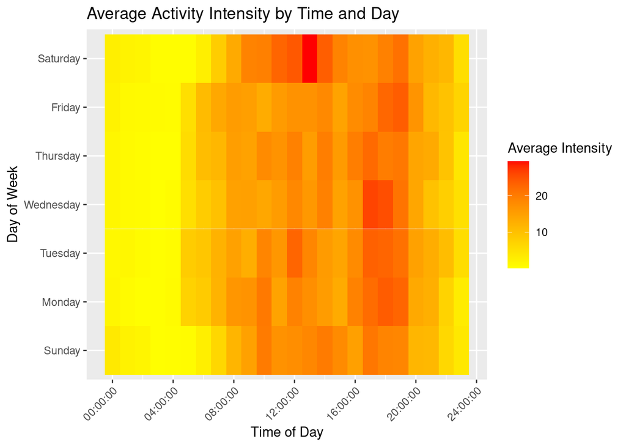

```r
print(ggplot(intensities_averages, aes(x = ActivityTime, y = day_of_week, fill = avg_total_intensity)) +
  geom_tile() +
  scale_fill_gradient(low = "yellow", high = "red") +
  labs(title = "Average Activity Intensity by Time and Day",
       x = "Time of Day",
       y = "Day of Week",
       fill = "Average Intensity") +
  theme(axis.text.x = element_text(angle = 45, hjust = 1))
      )
```

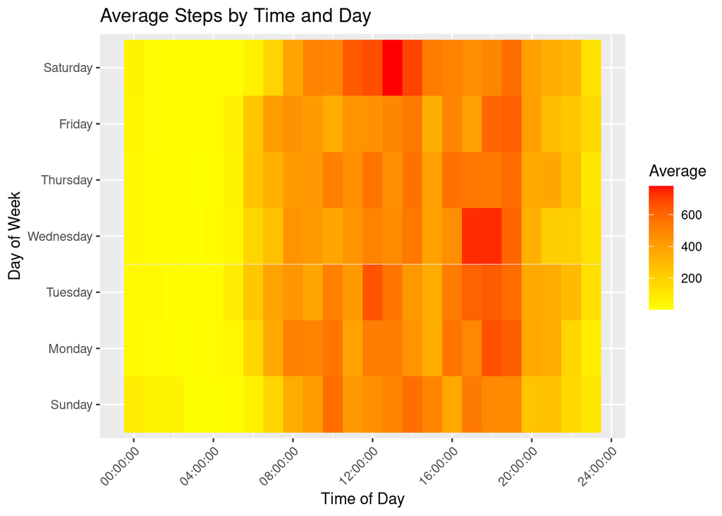

```r
print(ggplot(step_averages, aes(x = ActivityTime, y = day_of_week, fill = avg_step_total)) +
  geom_tile() +
  scale_fill_gradient(low = "yellow", high = "red") +
  labs(title = "Average Steps by Time and Day",
       x = "Time of Day",
       y = "Day of Week",
       fill = "Average") +
  theme(axis.text.x = element_text(angle = 45, hjust = 1))
      )
```

```r
# Unsurprisingly Average Steps by time and day strongly correlate to average intensities by day and hour.
cor.test(step_averages$avg_step_total, intensities_averages$avg_total_intensity)
```

```
##
##  Pearson's product-moment correlation
##
## data:  step_averages$avg_step_total and intensities_averages$avg_total_intensity
## t = 82.427, df = 166, p-value < 2.2e-16
## alternative hypothesis: true correlation is not equal to 0
## 95 percent confidence interval:
##  0.9837568 0.9911443
## sample estimates:
##       cor
## 0.9880031
```

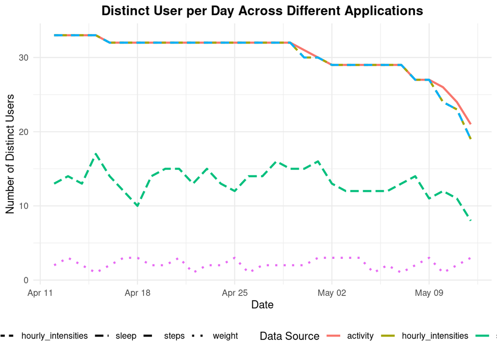

```r
# Now let's plot our data and check the visual
print(ggplot(combined_distinct_user_data, aes(x = Date, y = distinct_users, color = source, linetype = source)) +
  geom_line(linewidth = 1) +
  labs(
    title = "Distinct User per Day Across Different Applications",
    x = "Date",
    y = "Number of Distinct Users",
    color = "Data Source"
  ) + theme_minimal() +
  theme(
    plot.title = element_text(hjust = 0.5, face = "bold"),
    legend.position = "bottom"
  )
      )
```

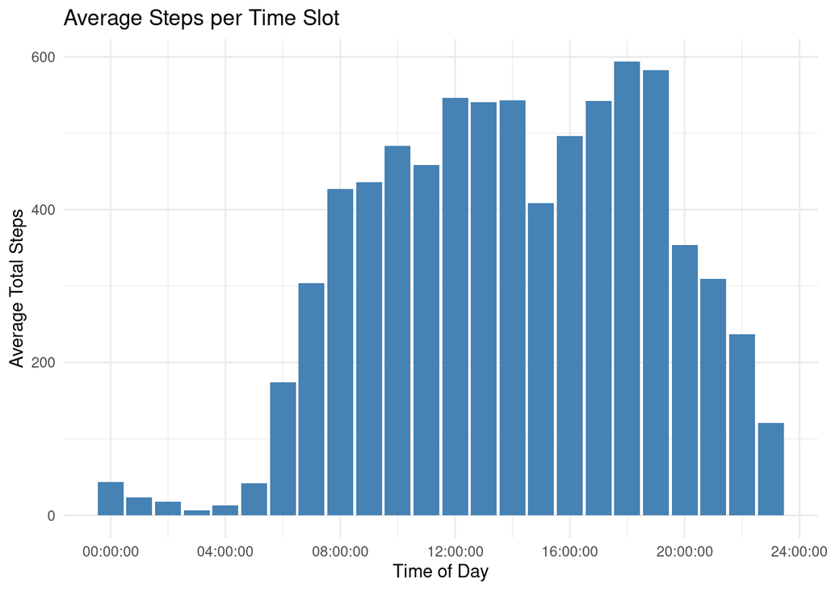

```r
# Here is an average steps per time slot graph.
print(ggplot(step_averages, aes(x = ActivityTime, y = (avg_step_total) / 7)) +
  geom_bar(stat = "identity", fill = "steelblue") +
  labs(
    title = "Average Steps per Time Slot",
    x = "Time of Day",
    y = "Average Total Steps"
  ) +
  theme_minimal()
      )
```

**An area of note is the overnight hours have low usage. This suggests two things a) biased sampling to the exclusion of 3rd shift workers, or b) people working 3rd shift are not buying/not using a Fitbit.**

**In order to evaluate the relationship between average calories and average steps, we need to scale the data. If you don’t scale the data, the visual – at least using this type of graphing – is not compelling or informative. This is accomplished by the self-explanatory code chunk below.**

```r
# This graph has a secondary axis to better highlight the relationship between calories and average steps per day.
scale_factor <- max(activity_weekly_averages$avg_steps) / max(activity_weekly_averages$avg_calories)
```

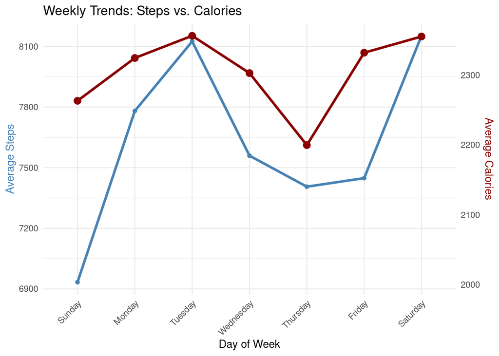

```r
print(ggplot(activity_weekly_averages, aes(x = day_of_week)) +
  geom_line(aes(y = avg_steps, group = 1), color = "steelblue", linewidth = 1.2) +
  geom_point(aes(y = avg_steps, group = 1), color = "steelblue", linewidth = 3) +
  geom_line(aes(y = avg_calories * scale_factor, group = 1), color = "darkred", size = 1.2) +
  geom_point(aes(y = avg_calories * scale_factor, group = 1), color = "darkred", size = 3) +
  labs(
    title = "Weekly Trends: Steps vs. Calories",
    x = "Day of Week",
    y = "Average Steps"
  ) +
  scale_y_continuous(
    sec.axis = sec_axis(~ . / scale_factor, name = "Average Calories")
  ) +
  theme_minimal() +
  theme(
    axis.text.x = element_text(angle = 45, hjust = 1),
    axis.title.y.left = element_text(color = "steelblue"),
    axis.title.y.right = element_text(color = "darkred")
  )
)
```

```r
# Combo Chart for sleep. You need to generate these so you can scale properly.
max_hours <- max(sleep_averages$avg_time_in_bed)
max_percent <- max(sleep_averages$winddown_percent)
scale_factor <- max_hours / max_percent
```

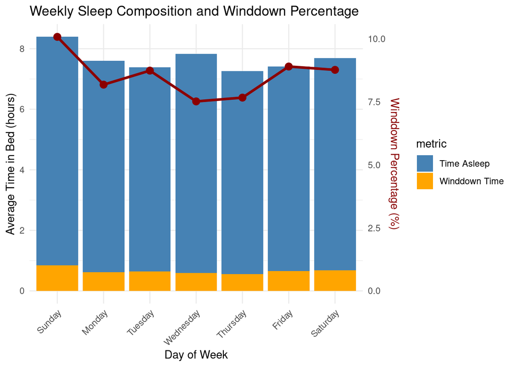

```r
print(ggplot(sleep_averages_long, aes(x = day_of_week)) +
  geom_bar(
    aes(y = hours, fill = metric),
    stat = "identity",
    position = "stack"
  ) +
  geom_line(
    data = sleep_averages,
    aes(y = winddown_percent * scale_factor, group = 1),
    color = "darkred",
    size = 1.2
  ) +
  geom_point(
    data = sleep_averages,
    aes(y = winddown_percent * scale_factor, group = 1),
    color = "darkred",
    size = 3
  ) +
  labs(
    title = "Weekly Sleep Composition and Winddown Percentage",
    x = "Day of Week",
    y = "Average Time in Bed (hours)",
    fill = "metric"
  ) +
  scale_y_continuous(
    name = "Average Time in Bed (hours)",
    sec.axis = sec_axis(~ . / scale_factor, name = "Winddown Percentage (%)")
  ) +
  scale_fill_manual(
    values = c("avg_sleep" = "steelblue", "avg_winddown" = "orange"),
    labels = c("avg_sleep" = "Time Asleep", "avg_winddown" = "Winddown Time")
  ) +
  theme_minimal() +
  theme(
    axis.text.x = element_text(angle = 45, hjust = 1),
    axis.title.y.right = element_text(color = "darkred")
  )
)
```

**It turns out, even Fitbit users are not eager to let the weekend go. Sunday night shows the largest percent of time in bed while not asleep on average. Also, most users are only getting around the minimum recommended amount of sleep per night (~7 hr/night for adults) according to the [Cleveland Clinic](https://health.clevelandclinic.org/your-complete-guide-to-sleep).**

**Our last visual is an evaluation of usage rates across applications per day against the summarized average use rates.**

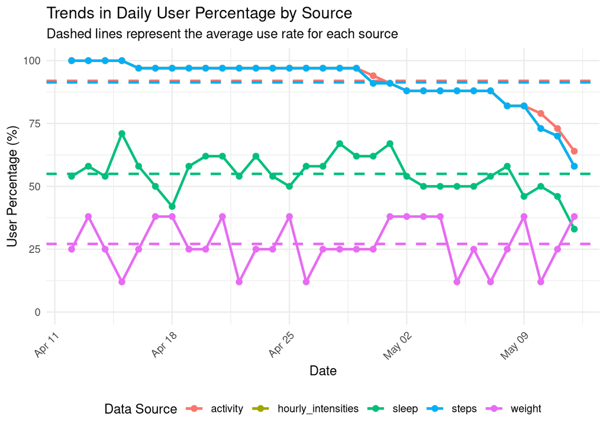

```r
print(ggplot(combined_distinct_data_with_percent, aes(x = Date, y = percent_of_users, color = source, group = source)) +
  geom_line(size = 1) +
  geom_point(size = 2) +
  geom_hline(
    data = average_use_rate,
    aes(yintercept = average_percent, color = source),
    linetype = "dashed",
    size = 1
  ) +
  labs(
    title = "Trends in Daily User Percentage by Source",
    subtitle = "Dashed lines represent the average use rate for each source",
    x = "Date",
    y = "User Percentage (%)",
    color = "Data Source"
  ) +
  theme_minimal() +
  scale_y_continuous(limits = c(0, 100)) +
  theme(
    axis.text.x = element_text(angle = 45, hjust = 1),
    legend.position = "bottom"
  )
)
```

```r
# View(average_use_rate)
```

# SHARE

## Key Takeaways

In evaluating this dataset for user trends the following were my key takeaways: - The manual applications are under utilized. Slightly more than half the available users any given day utilize the sleep functionality and slightly over a quarter utilize the weight application. - 3rd Shift workers represent a poorly monetized market segment. - There is no statistically meaningful variance between days of the week from a usage perspective. This means the product, once purchased, is utilized throughout the week at about the same rates.

## SUMMARY

The Fitbit data set was limited by time and by available unique users. We learned most of the automated applications are utilized at a high rate by Fitbit owners. Of the applications we evaluated which require additional inputs from users, sleep is twice as utilized as weight. This suggests buyers interested in tracking their weight use a different application altogether or represent a smaller-than-expected percentage of the target user population. In keeping with the name, Fitbit users seem less inclined to consider weight in the same way they do other stay-healthy metrics (the preponderance of users may already be fit).

An opportunity to simplify downstream analyses by changing the schema and storage of Bellabeat user data exists. The database engineering team and data architects have an opportunity to produce a better end-user product simply by properly storing a date, as a date datatype rather than a character string. The same can be applied to time and it is likely not a significant time outlay to add weekday columns to the schema.

Most of the problem-solving skill I applied had to do with data transformation and moving work from the POSIT rStudio environment over to Kaggle. Also, there were several difficult-for-me coding errors arising from poor naming conventions, failure to predict downstream defects and most all of the issues associated with limited coding skills and being a first-timer. I leveraged gen-AI to help lessen the gap between my skills and the ability to turn curiosity into meaningful visuals more directly.

# ACT

## NEXT STEPS

1. Marketing Team: Develop qualitative and quantitative surveys for demographic data on Fitbit or similar wellness wearables along with a user feedback survey covering all available applications.
2. Programming team: develop and deploy a voice command feature for all manual applications. Track and report the resulting delta usage rates to ownership.
3. Database Architect/Engineering Team: change data storage structure for date and time data to store as date and time types. Edit schema to include a weekday column.
4. Marketing Team: Create tailored marketing campaigns for underrepresented target market segments.
5. Marketing Team: Evaluate the efficacy of approach through a second series of surveys and user feedback.